Capital One Data Challenge

Anudeep Mukka  
January 9, 2020

[figure not shown]

# Introduction

## Problem Statement

You are consulting for a real estate company that has a niche in purchasing properties to rent out short-term as part of their business model specifically within New York City. The real estate company has already concluded that two-bedroom properties are the most profitable; however, they do not know which zip codes are the best to invest in.

The real estate company has engaged your firm to build out a data product and provide your conclusions to help them understand which zip codes would generate the most profit on short term rentals within New York City.

You will be looking at publicly available data from Zillow and Airbnb:

- Cost data: Zillow provides us an estimate of value for two-bedroom properties
- Revenue data: Airbnb is the medium through which the investor plans to lease out their investment property. Fortunately for you, we are able to see how much properties in certain neighbourhoods rent out for in New York City

## Assumptions

# Product Overview

This data product takes Zillow dataset which contains historical property prices for various zip codes and Airbnb dataset which contains information about neighbourhood properties in various zipcodes as inputs. Quantitative metrics like revenue, profit, payback period, property growth and qualitative metrics like population size, number of super hosts have been used to recommend final zips. I have done all the analysis on 2 Bedroom properties in "New York" city. I have avoided hard-coding wherever possible and defined various functions which are driven by variables defined in "Input Variables" section to clean the data, derive new metrics and perform analysis on the data. This makes it reusable to solve similar business challenges.

# Importing Libraries

```python
import pandas as pd
import numpy as np
import matplotlib.pyplot as plt
import seaborn as sns
import warnings
warnings.filterwarnings('ignore')
```

```python
%%html
<style>
table {float:left}
</style>
```

# Input Variables

Following variables are used for data cleaning, manipulation and analysis. **Any changes to the code have to be made here**. Below is the description of each variable

| Variable | Description |
| --- | --- |
| Invalid_Zip_Codes | Invalid zip codes to be deleted from the airbnb dataset |
| square_feet_threshold | Minimum square feet of the property below which the property will not be considered for the analysis |
| price_threshold | Max daily rental price of the property above which the property will not be considered for the analysis |
| City_Name | City of interest |
| Bedroom_size | Bedroom size of interest |
| Investment_Date | Year and month on which the property will be bought |
| Occupancy rate | Average occupancy rate |
| years | Historical years to be considered to calculate property average growth and forecast propert value for future years |
| maintainance_cost | Yearly maintainance cost for a property in terms of % of yearly revenue generated |

```python
#Data Cleaning Variables
Invalid_Zip_Codes = ['11249\n11249','11103-3233','10002-2289','11385-2308','11413-3220','11692-2304']
square_feet_threshold = 100
price_threshold = 2000

# Data Manipulation Variables
City_Name = 'New York'
Bedroom_size = 2
Occupancy_rate = 0.75
Investment_Date = '2017-06'
years = [2014,2015,2016,2017]
forecast_5_year = str(years[-1]+5)+'-'+'06'
maintainance_cost = 0.05
```

# Data Loading

```python
listing = pd.read_csv("listings.csv")
```

```python
zillow = pd.read_csv("Zip_Zhvi_2bedroom.csv")
```

```python
listing_subset = listing.loc[:,['host_is_superhost','neighbourhood_group_cleansed','city','state','zipcode','room_type','bedrooms','price','square_feet']]
```

I have considered following variables for the analysis:

**Zillow Dataset**

| Variable | Description |
| --- | --- |
| RegionName | Zip code of where the property is located |
| City | City of where the property is located |
| SizeRank | Population of the area; the lower the number the greater the population. |
| 1996-04 – 2017-06 | Indicates the historical median price within that area |

**Airbnb Dataset**

| Variable | Description |
| --- | --- |
| host_is_superhost | Experienced hosts who provide a shining example for other hosts |
| neighbourhood_group_cleansed | Name of the area where the property is located |
| city | City where the property is located |
| state | State where the property is located |
| zipcode | Zip code where the property is located |
| room_type | Indicates specific rooms available for rent and/or the entire home |
| bedrooms | Indicates the number of bedrooms within the property |
| price | Price the host is charging to stay per night |
| square_feet | Square footage of the property or space for rent |

**Derived Metrics**

| Variable | Description | Present in which datasets? |
| --- | --- | --- |
| Average_Growth | Average property growth of properties for last 3 years | zillow_subset |
| profit | Yearly profit of properties based on occupancy rate, daily rental price and maintainance cost | Revenue_Data |
| median_profit | Median yearly profits for various zipcodes obtained from yearly profits of properties | Revenue_Data |
| pay_back_period | Time in years to recover money invested in a property | Revenue_Data |
| 2018-06 | Property value forecast for 2018-06 | zillow_subset |
| 2019-06 | Property value forecast for 2019-06 | zillow_subset |
| 2020-06 | Property value forecast for 2020-06 | zillow_subset |
| 2021-06 | Property value forecast for 2021-06 | zillow_subset |
| 2022-06 | Property value forecast for 2022-06 | zillow_subset,listing_merged,Revenue_Data |

# Data Cleaning

Following data cleaning steps have been done:

- Removed duplicates in listing dataset (1.06%)
- Removed properties from listing dataset which has null zip values (1.05%)
- Removed invalid zipcodes from listing dataset whose length is more than 5 (eg: '11249\n11249')
- Removed properties with a daily rental price greater than 2000
- Removed Properties with square feet less than 100
- Removed special characters like '$' and ',' from price columns
- Converted datatype of price to float and zipcodes to character
- Properties in zip code '10013' which are mislisted under Brooklyn neighbourhood group have been changed to the Manhattan neighbourhood group

```python
# Removing duplicate records
listing_subset = listing_subset.loc[~(listing_subset.duplicated(subset=None, keep='first')),:]
# Removing records with null zip values
listing_subset = listing_subset.loc[listing_subset['zipcode'].notnull(),:]
#Removing records with invalid zip values
listing_subset = listing_subset.loc[(~listing_subset['zipcode'].isin(Invalid_Zip_Codes)),:]
#Removing properties with square feet less than 100
listing_subset = listing_subset.loc[~(listing_subset['square_feet']< square_feet_threshold),:]
#Realigining neighbourhood_group to 10013 zipcode
listing_subset.loc[listing_subset['zipcode']=='10013','neighbourhood_group_cleansed'] = 'Manhattan'
#Converting zipcode datatype to string
listing_subset['zipcode'] = [str(x) for x in listing_subset['zipcode']]
zillow['RegionName'] = [str(x) for x in zillow['RegionName']]
```

```python
def price_clean(x):
    #checking for nan values
    if x != x:
        x= float('nan')
    else:
        x = x.replace('$','')
        x = x.replace(',','')
    return x
```

```python
listing_subset['price'] = listing_subset['price'].apply(price_clean)
```

```python
listing_subset['price'] = [float(x) for x in listing_subset['price']]
```

```python
listing_subset = listing_subset.loc[~(listing_subset['price']> price_threshold),:]
```

# Data Manipulation

Following steps have been performed in this section:

- Filtered Zillow dataset for "New York" city
- Price correction has been applied to properties which offer private rooms. The given price is multiplied by the number of bedrooms to get the actual price
- Forecasted property prices for the next 5 years
- Merged listing and Zillow datasets on zipcode
- Revenue and Pay Back Period is calculated

```python
zillow_subset = zillow.loc[zillow['City']==City_Name,:]
```

```python
def price_correction(x):
    if x['room_type'] == 'Private room':
        corrected_price = x['price']*x['bedrooms']
    else:
        corrected_price = x['price']
    return corrected_price
```

```python
listing_subset['price'] = listing_subset.apply(price_correction,axis = 1)
```

```python
listing_subset['occupancy_rate'] = Occupancy_rate
```

## Property value for next 5 years

The Zillow dataset has past prices of the two-bedroom houses. In this section, I have tried to forecast the next 5 years of growth in the property prices based on the historic 3 years data. This is achieved by calculating the average year on year growth over the last 3 years and treating the average constant for the next 5 years. Also, since we are interested in 2 bedroom properties I have filtered the merged dataset for 2 bedroom properties

```python
def avg_growth(x,start_year,end_year):
    Growth = []
    for i in range(start_year,end_year,1):
        past_year_month = str(i)+'-'+'06'
        present_year_month = str(i+1)+'-'+'06'
        Growth.append(((x[present_year_month]/x[past_year_month])-1))

    return np.mean(Growth)
```

```python
def forecast(x,year):
    previous_year_month = str(year-1)+'-'+'06'
    return (1+x['Average_Growth'])*(x[previous_year_month])
```

```python
zillow_subset['Average_Growth'] = zillow_subset.apply(avg_growth,axis = 1,start_year= years[0],end_year = years[-1])
zillow_subset[str(years[-1]+1)+'-'+'06'] = zillow_subset.apply(forecast,axis =1 , year=years[-1]+1)
zillow_subset[str(years[-1]+2)+'-'+'06'] = zillow_subset.apply(forecast,axis =1 , year=years[-1]+2)
zillow_subset[str(years[-1]+3)+'-'+'06'] = zillow_subset.apply(forecast,axis =1 , year=years[-1]+3)
zillow_subset[str(years[-1]+4)+'-'+'06'] = zillow_subset.apply(forecast,axis =1 , year=years[-1]+4)
zillow_subset[str(years[-1]+5)+'-'+'06'] = zillow_subset.apply(forecast,axis =1 , year=years[-1]+5)
```

```python
listing_merged = pd.merge(listing_subset,zillow_subset[['RegionName','SizeRank',Investment_Date,forecast_5_year]],left_on = 'zipcode',
                          right_on = 'RegionName',how = 'inner')
```

```python
listing_merged = listing_merged.loc[listing_merged['bedrooms']==Bedroom_size,:]
```

## Revenue, Profit and Break Even Calculations

Yearly revenue for a property is calculated using the occupancy rate and daily price of the property. I have considered 5% of the total revenue generated by a property goes towards maintenance costs and calculated yearly profit by taking off this cost from the revenue

```python
def profit(x):
    Revenue_per_year = x['occupancy_rate'] * x['price'] *365
    Profit_per_year = (1-maintainance_cost)*Revenue_per_year
    return Profit_per_year
```

```python
listing_merged['profit'] = listing_merged.apply(profit,axis = 1)
```

We can see from the below distribution that yearly profit is not normally distributed. I have considered the median yearly profit of properties to arrive at the yearly profit generated for each zip

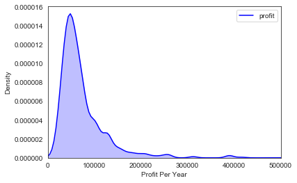

```python
sns.set_style("white")
sns.kdeplot(listing_merged['profit'],color = 'blue',shade = True);
plt.xlim(0,500000);
plt.xlabel('Profit Per Year');
plt.ylabel('Density');
```

```python
median_profits = listing_merged.groupby('zipcode',as_index = False).aggregate({'profit':'median'})
median_profits.columns = ['zipcode','median_profit']
Revenue_Data = pd.merge(listing_merged,median_profits,left_on = 'zipcode',right_on = 'zipcode',how ='left')
```

Pay Back Period for each zip code is calculated using the amount invested in buying a property and yearly profit. It measures the amount of time in years taken to get the amount invested in a property

```python
def break_even_year(x):
    years = x[Investment_Date]/x['median_profit']
    return years
```

```python
Revenue_Data['pay_back_period'] = Revenue_Data.apply(break_even_year,axis = 1)
```

```python
Revenue_Data = Revenue_Data.drop(columns = ['city','state','RegionName','bedrooms','room_type','square_feet'])
```

# Analysis

## Popular Zipcodes

We can see from the below distribution that Manhattan has the highest number of properties listed(63.4%) followed by Brooklyn(34.2%), Staten Island(1.9%) and Queens(0.5%). We can be very sure of any inferences obtained from Manhatten and Brooklyn properties as they have more data points and they would be reflective of the true population. Queens Island contains only 1 zip with four properties in it and hence the sample wouldn't be a true representation of the population. Zipcodes **11215,11217 and 10003** are leading in terms of # of properties listed.

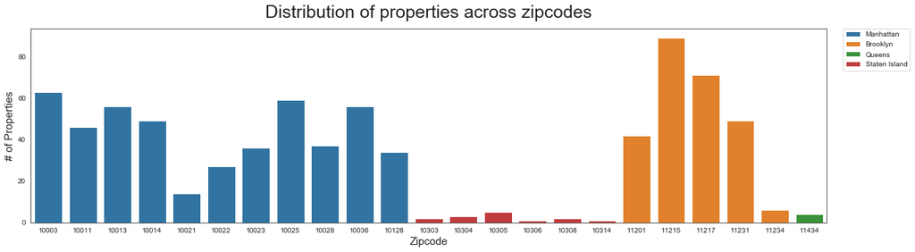

```python
%matplotlib inline
plt.figure(figsize=(20,5))
chart = sns.countplot(x = 'zipcode',hue = 'neighbourhood_group_cleansed',dodge= False,data = Revenue_Data);
plt.xlabel('Zipcode',fontsize=15);
plt.ylabel('# of Properties',fontsize=15);
sns.set_style("white")
plt.legend(bbox_to_anchor=(1.02, 1), loc=2, borderaxespad=0.)
plt.title("Distribution of properties across zipcodes",fontsize = 25,pad=15);
plt.show()
```

## Payback period for various zipcodes

The below scatterplot shows that properties in Manhattan have higher payback period and takes a longer time to break even the investment which is followed by Brooklyn, Staten Island and Queens. This is because the cost price of properties in Manhattan and Brooklyn are relatively higher compared to properties in other boroughs while the daily rental price is not substantially different among these boroughs which have led to different payback periods. Zipcodes such as **10308,11434 and 10314** have a lower payback period

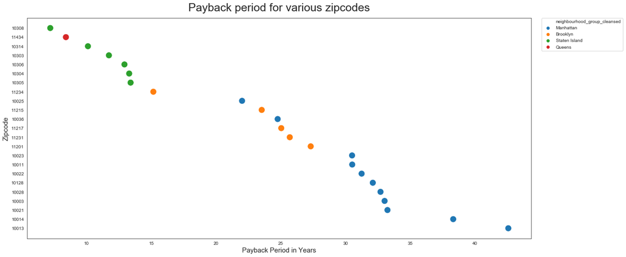

```python
plt.figure(figsize=(20,9))
Revenue_Data = Revenue_Data.sort_values(by =['pay_back_period'],ascending = False)
sns.scatterplot(x='pay_back_period',y = 'zipcode',hue = 'neighbourhood_group_cleansed',data = Revenue_Data,s = 200);
plt.xlabel('Payback Period in Years',fontsize=15);
plt.ylabel('Zipcode',fontsize=15);
plt.title("")
plt.legend(bbox_to_anchor=(1.02, 1), loc=2, borderaxespad=0.);
plt.title("Payback period for various zipcodes",fontsize = 25,pad=15);
plt.show();
```

## Does higher investment always guarantee higher returns??

In general, properties in Manhattan are relatively expensive than properties in other boroughs. We can also see that profit is not always directly proportional to investment. The Cost price of a property in 10011 zipcode(Manhattan borough) is significantly lesser than property in 10013 but the properties in 10011 generate higher profits. Hence, we cannot be very sure that higher investment always guarantee higher returns

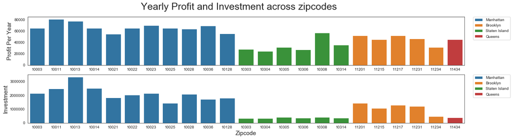

```python
fig,ax = plt.subplots(2,1,figsize=(20,5))
fig.suptitle('Yearly Profit and Investment across zipcodes', fontsize=25)

# Plot 1
sns.barplot(x='zipcode',y = 'median_profit',hue = 'neighbourhood_group_cleansed',dodge = False, data = Revenue_Data,ax = ax[0]);
ax[0].legend(bbox_to_anchor=(1.02, 1), loc=2, borderaxespad=0.)
ax[0].set_xlabel('',fontsize = 15)
ax[0].set_ylabel('Profit Per Year',fontsize = 15)
# Plot 2
sns.barplot(x='zipcode',y = Investment_Date,hue = 'neighbourhood_group_cleansed',dodge = False, data = Revenue_Data,ax =ax[1]);
ax[1].legend(bbox_to_anchor=(1.02, 1), loc=2, borderaxespad=0.)
ax[1].set_xlabel('Zipcode',fontsize = 15)
ax[1].set_ylabel('Investment',fontsize = 15)
plt.show();
```

## How are properties growing??

Property growth is an important factor in deciding which property to purchase. In general growth of properties in Manhattan is relatively lower compared to properties in other boroughs with an exception of zipcode 10128. This is because the initial investment in these properties are higher and hence, the growth is slower. Zipcodes such as **10128,11217 and 10304** are leading in terms of property growth

```python
df1 = Revenue_Data[['zipcode',Investment_Date,'neighbourhood_group_cleansed',forecast_5_year]]
for index,row in df1.iterrows():
    df1.loc[index,'Growth'] = 100+((row[forecast_5_year]-row[Investment_Date])/row[Investment_Date])*100
df1 = df1.sort_values(by = ['Growth'],ascending = False)
df1 = df1.reset_index(drop = True)
```

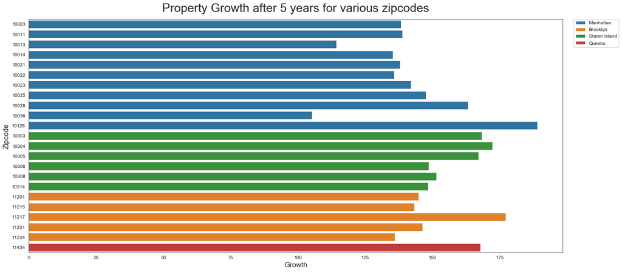

```python
df2 = df1.groupby(['zipcode','neighbourhood_group_cleansed'],as_index = False).aggregate({'Growth':'mean'})
df2 = df2.sort_values(by = ['Growth'],ascending = True)
df2=df2.reset_index(drop = True)
plt.figure(figsize=(20,9));
sns.barplot(y='zipcode',x='Growth',hue = 'neighbourhood_group_cleansed',dodge=False,orient='h',data = df2);
plt.xlabel('Growth',fontsize=15);
plt.ylabel('Zipcode',fontsize=15);
plt.legend(bbox_to_anchor=(1.02, 1), loc=2, borderaxespad=0.);
plt.title("Property Growth after 5 years for various zipcodes",fontsize = 25,pad=15);
```